# Evaluación de la Oferta Inmobiliaria Urbana

Alvaro Pérez Niño

Febrero de 2024

# Problema

Una empresa inmobiliaria líder en una gran ciudad está buscando comprender en profundidad el mercado de viviendas urbanas para tomar decisiones estratégicas más informadas. La empresa posee una base de datos extensa que contiene información detallada sobre diversas propiedades residenciales disponibles en el mercado. Se requiere realizar un análisis holístico de estos datos para identificar patrones, relaciones y segmentaciones relevantes que permitan mejorar la toma de decisiones en cuanto a la compra, venta y valoración de propiedades.

```r
library(paqueteMODELOS)
```

```r
dataset_vivienda <- vivienda
str(dataset_vivienda)
```

```
##  $ id          : num [1:8322] 1147 1169 1350 5992 1212 ...
##  $ zona        : chr [1:8322] "Zona Oriente" "Zona Oriente" "Zona Oriente" "Zona Sur" ...
##  $ piso        : chr [1:8322] NA NA NA "02" ...
##  $ estrato     : num [1:8322] 3 3 3 4 5 5 4 5 5 5 ...
##  $ preciom     : num [1:8322] 250 320 350 400 260 240 220 310 320 780 ...
##  $ areaconst   : num [1:8322] 70 120 220 280 90 87 52 137 150 380 ...
##  $ parqueaderos: num [1:8322] 1 1 2 3 1 1 2 2 2 2 ...
##  $ banios      : num [1:8322] 3 2 2 5 2 3 2 3 4 3 ...
##  $ habitaciones: num [1:8322] 6 3 4 3 3 3 3 4 6 3 ...
##  $ tipo        : chr [1:8322] "Casa" "Casa" "Casa" "Casa" ...
##  $ barrio      : chr [1:8322] "20 de julio" "20 de julio" "20 de julio" "3 de julio" ...
##  $ longitud    : num [1:8322] -76.5 -76.5 -76.5 -76.5 -76.5 ...
##  $ latitud     : num [1:8322] 3.43 3.43 3.44 3.44 3.46 ...
```

## Retos

El reto principal consisten en realizar un análisis integral y multidimensional de la base de datos para obtener una comprensión del mercado inmobiliario urbano. Se requiere aplicar diversas técnicas de análisis de datos, incluyendo:

1. Análisis de Componentes Principales
2. Análisis de Conglomerados
3. Análisis de Correspondencia
4. Visualización de resultados

# Solución

## 0. Cargue de librerias requeridas

```r
# Gestionar las bibliotecas necesarias
library(ggplot2)
library(gridExtra)
library(dplyr)
library(mice)
library(tidyverse)
library(corrplot)
library(psych)
library(factoextra)
library(GGally)
library(knitr)
library(cluster)
library(FactoMineR)
library(factoextra)
```

## 1. Entendimiento de los datos

**1.1 Número de registros y atributos**

```r
# Obtener el número de filas
num_filas <- nrow(dataset_vivienda)
# Obtener el número de columnas
num_columnas <- ncol(dataset_vivienda)
# Mostrar en pantalla resultado
cat("Registros: ",num_filas," y Atributos: ",num_columnas)
```

```
## Registros:  8322  y Atributos:  13
```

**1.2 Obtener los tipos de datos de los atribitos**

```r
# Obtener los tipos de datos de los atribitos
tipos_datos <- sapply(dataset_vivienda, typeof)
print(tipos_datos)
```

```
##           id         zona         piso      estrato      preciom    areaconst
##     "double"  "character"  "character"     "double"     "double"     "double"
## parqueaderos       banios habitaciones         tipo       barrio     longitud
##     "double"     "double"     "double"  "character"  "character"     "double"
##      latitud
##     "double"
```

**1.3 Cantidad de datos faltantes por atribito**

```r
# Calcular la suma de valores faltantes por columna
suma_valores_faltantes <- colSums(is.na(dataset_vivienda))

# Mostrar el resultado
print(suma_valores_faltantes)
```

```
##           id         zona         piso      estrato      preciom    areaconst
##            3            3         2638            3            2            3
## parqueaderos       banios habitaciones         tipo       barrio     longitud
##         1605            3            3            3            3            3
##      latitud
##            3
```

**1.4 Descripción estadística General**

```r
# Descripción estadística
summary(dataset_vivienda)
```

```
##        id           zona               piso              estrato
##  Min.   :   1   Length:8322        Length:8322        Min.   :3.000
##  1st Qu.:2080   Class :character   Class :character   1st Qu.:4.000
##  Median :4160   Mode  :character   Mode  :character   Median :5.000
##  Mean   :4160                                         Mean   :4.634
##  3rd Qu.:6240                                         3rd Qu.:5.000
##  Max.   :8319                                         Max.   :6.000
##  NA's   :3                                            NA's   :3
##     preciom         areaconst       parqueaderos        banios
##  Min.   :  58.0   Min.   :  30.0   Min.   : 1.000   Min.   : 0.000
##  1st Qu.: 220.0   1st Qu.:  80.0   1st Qu.: 1.000   1st Qu.: 2.000
##  Median : 330.0   Median : 123.0   Median : 2.000   Median : 3.000
##  Mean   : 433.9   Mean   : 174.9   Mean   : 1.835   Mean   : 3.111
##  3rd Qu.: 540.0   3rd Qu.: 229.0   3rd Qu.: 2.000   3rd Qu.: 4.000
##  Max.   :1999.0   Max.   :1745.0   Max.   :10.000   Max.   :10.000
##  NA's   :2        NA's   :3        NA's   :1605     NA's   :3
##   habitaciones        tipo              barrio             longitud
##  Min.   : 0.000   Length:8322        Length:8322        Min.   :-76.59
##  1st Qu.: 3.000   Class :character   Class :character   1st Qu.:-76.54
##  Median : 3.000   Mode  :character   Mode  :character   Median :-76.53
##  Mean   : 3.605                                         Mean   :-76.53
##  3rd Qu.: 4.000                                         3rd Qu.:-76.52
##  Max.   :10.000                                         Max.   :-76.46
##  NA's   :3                                              NA's   :3
##     latitud
##  Min.   :3.333
##  1st Qu.:3.381
##  Median :3.416
##  Mean   :3.418
##  3rd Qu.:3.452
##  Max.   :3.498
##  NA's   :3
```

**1.4.1 Gráfico de las Variables Cuantitativas**

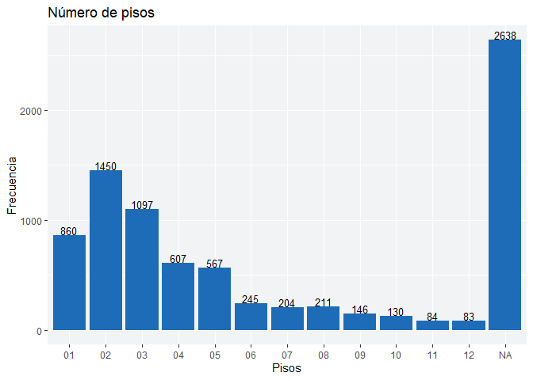

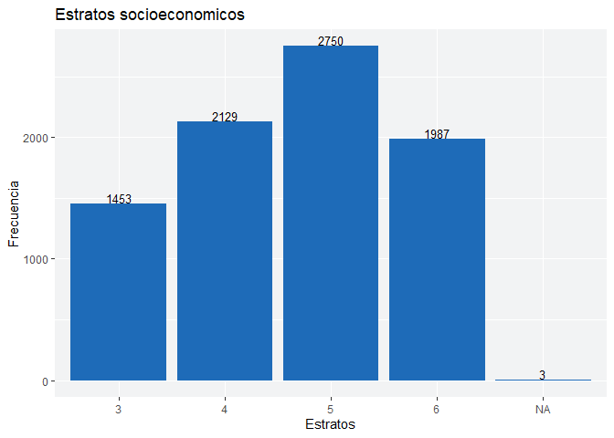

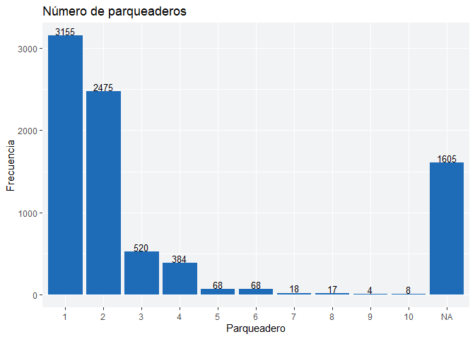

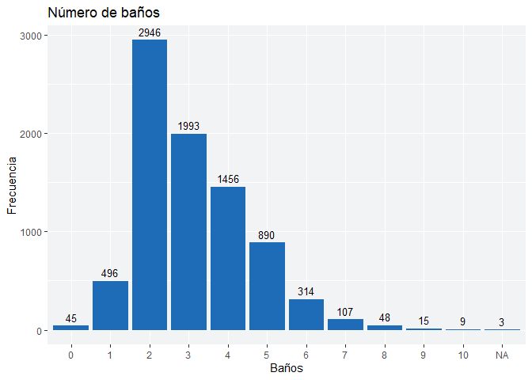

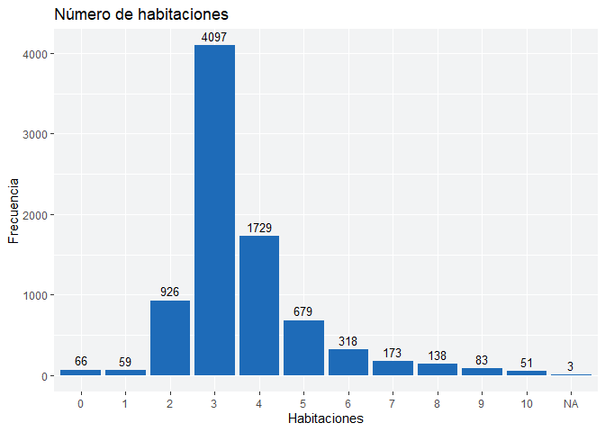

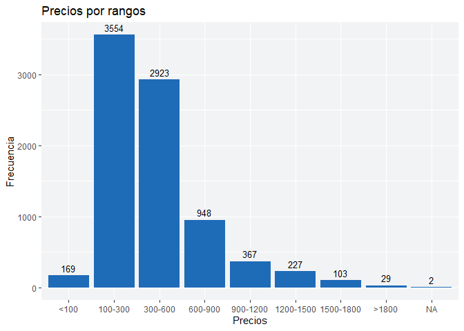

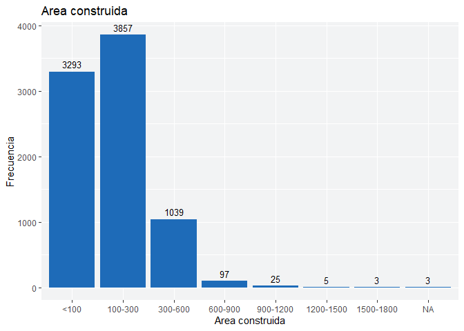

**1.4.2 Gráfico de las Variables Cualitativas**

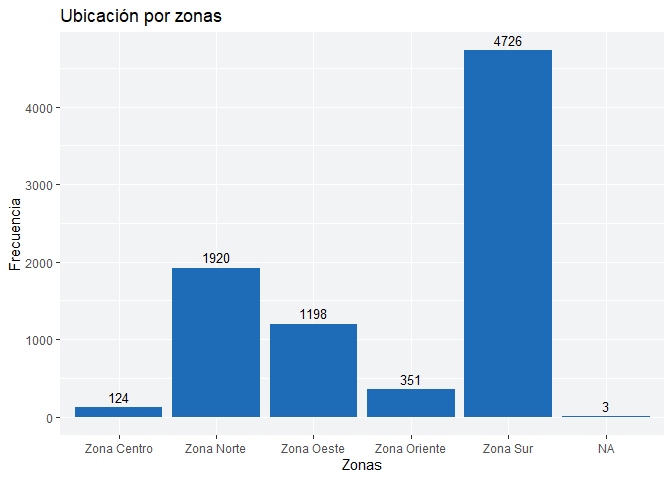

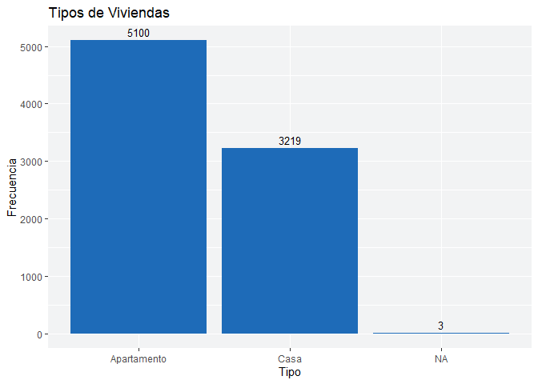

**1.5 Análisis del dataset**

Debido a las inconsistencias mencionadas, se procede a normalizar el conjunto de datos antes de aplicar diversas técnicas de análisis.

## 2. Preparación de los datos

**2.1 Eliminar el ID como dato irrelevante del dataset**

```r
#  Eliminar el ID como dato irrelevante del dataset
dataset_vivienda=select(dataset_vivienda, -id)
```

**2.2 Convertir el tipo de dato en el atributo “Piso” de Caracteres a Numérico**

```r
# Convertir el tipo de dato en el atributo "Piso"
dataset_vivienda$piso <- as.numeric(dataset_vivienda$piso)
```

**2.3 Imputación de registros para completar los datos faltantes**

```r
# Número de pisos
media_piso <- mean(dataset_vivienda$piso[dataset_vivienda$piso != 0 &
  !is.na(dataset_vivienda$piso)], na.rm = TRUE)
media_piso <- round(media_piso)
dataset_vivienda <- dataset_vivienda %>% mutate(piso = ifelse(piso == 0 |
  is.na(piso), media_piso, piso))

# Estrato socioeconomico
media_estrato <- mean(dataset_vivienda$estrato[dataset_vivienda$estrato != 0 &
  !is.na(dataset_vivienda$estrato)], na.rm = TRUE)
media_estrato <- round(media_estrato)
dataset_vivienda <- dataset_vivienda %>% mutate(estrato = ifelse(estrato == 0 |
  is.na(estrato), media_estrato, estrato))

# Número de parqueaderos
media_parquea <- mean(dataset_vivienda$parqueaderos[dataset_vivienda$parqueaderos != 0
  & !is.na(dataset_vivienda$parqueaderos)], na.rm = TRUE)
media_parquea <- round(media_parquea)
dataset_vivienda <- dataset_vivienda %>% mutate(parqueaderos = ifelse(parqueaderos == 0 |
  is.na(parqueaderos), media_parquea, parqueaderos))

# Número de baños
media_banios <- mean(dataset_vivienda$banios[dataset_vivienda$banios != 0 &
  !is.na(dataset_vivienda$banios)], na.rm = TRUE)
media_banios <- round(media_banios)
dataset_vivienda <- dataset_vivienda %>% mutate(banios = ifelse(banios == 0 |
  is.na(banios), media_banios, banios))

# Número de habitaciones
media_habitac <- mean(dataset_vivienda$habitaciones[dataset_vivienda$habitaciones != 0 &
  !is.na(dataset_vivienda$habitaciones)], na.rm = TRUE)
media_habitac <- round(media_habitac)
dataset_vivienda <- dataset_vivienda %>% mutate(habitaciones = ifelse(habitaciones == 0 |
  is.na(habitaciones), media_habitac, habitaciones))
```

**2.4 Eliminar los registros totalmente incompletos**

```r
# Eliminar los registros incompletos
dataset_vivienda <- dataset_vivienda[complete.cases(dataset_vivienda), ]
```

**2.5 Verificación de la normalización del dataset**

```
##  /\     /\
## {  `---'  }
## {  O   O  }
## ==>  V <==  No need for mice. This data set is completely observed.
##  \  \|/  /
##   `-----'
```

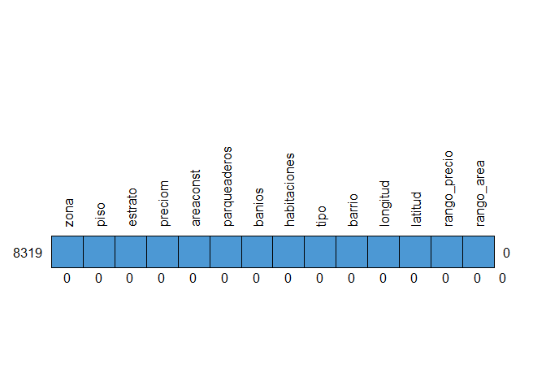

```
##      zona piso estrato preciom areaconst parqueaderos banios habitaciones tipo
## 8319    1    1       1       1         1            1      1            1    1
##         0    0       0       0         0            0      0            0    0
##      barrio longitud latitud rango_precio rango_area
## 8319      1        1       1            1          1 0
##           0        0       0            0          0 0
```

```r
# Verificar los datos faltantes
md.pattern(dataset_vivienda, rotate.names = TRUE)
```

**2.6 Transformar los atributos categóricos en numéricos**

```r
# Transformación de atributos
# Ubicacion por Zona
dataset_vivienda$zona_numerica <- as.numeric(factor(dataset_vivienda$zona,
  levels = c("Zona Centro", "Zona Norte", "Zona Oeste", "Zona Oriente", "Zona Sur")))

# Tipo de inmueble
dataset_vivienda$tipo_numerica <- as.numeric(factor(dataset_vivienda$tipo,
  levels = c("Apartamento", "Casa")))
```

## 3. Análisis de datos

### 3.1 Análisis de Componentes Principales

Para el análisis de componentes principales PCA, no se tendran encuenta los atributos complementarios (barrio, longitud y latitud), debido a que son unicamente utilizadas para una visualización espacial y al igual de los atributos generados para el análisis estadístico.

**3.1.1 Adecuación preliminar del dataset**

```r
# Adecuación preliminar
dataset_PCA=select(dataset_vivienda, -zona, -tipo, -barrio, -longitud, -latitud,
                   -rango_precio,   -rango_area)
```

**3.1.2 Correlación de los atributos del dataset**

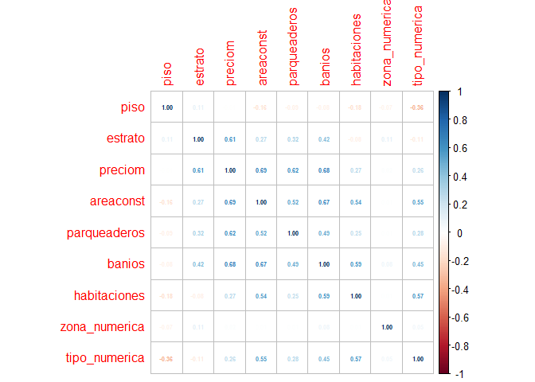

```r
# Correlación de los atributos del dataset
matrizcor <- cor(dataset_PCA)
corrplot (matrizcor, method = "number", number.cex = 0.5, addCoef.col = "#034D94")
```

El análisis de correlaciones evidencia una fuerte relacion entre los atributos: precio, áera construida, parqueaderos y baños; donde se puede inferir que el **precio** de la vivienda es directamente proporcional al áera construida, parqueaderos y baños.

Con el fin de determinar la pertinencia del PCA para el dataset se realiza la medición de KMO y prueba de Barlett:

```r
# Medición de KMO y prueba de Barlett
resultado_prueba <- psych::corr.test(matrizcor)
print(resultado_prueba)
```

```
## Call:psych::corr.test(x = matrizcor)
## Correlation matrix
##                piso estrato preciom areaconst parqueaderos banios habitaciones
## piso           1.00    0.09   -0.37     -0.69        -0.46  -0.61        -0.66
## estrato        0.09    1.00    0.65      0.09         0.34   0.26        -0.45
## preciom       -0.37    0.65    1.00      0.75         0.78   0.78         0.20
## areaconst     -0.69    0.09    0.75      1.00         0.68   0.86         0.70
## parqueaderos  -0.46    0.34    0.78      0.68         1.00   0.64         0.26
## banios        -0.61    0.26    0.78      0.86         0.64   1.00         0.68
## habitaciones  -0.66   -0.45    0.20      0.70         0.26   0.68         1.00
## zona_numerica -0.17   -0.11   -0.42     -0.42        -0.39  -0.39        -0.29
## tipo_numerica -0.82   -0.45    0.20      0.72         0.32   0.58         0.84
##               zona_numerica tipo_numerica
## piso                  -0.17         -0.82
## estrato               -0.11         -0.45
## preciom               -0.42          0.20
## areaconst             -0.42          0.72
## parqueaderos          -0.39          0.32
## banios                -0.39          0.58
## habitaciones          -0.29          0.84
## zona_numerica          1.00         -0.18
## tipo_numerica         -0.18          1.00
## Sample Size
## [1] 9
## Probability values (Entries above the diagonal are adjusted for multiple tests.)
##               piso estrato preciom areaconst parqueaderos banios habitaciones
## piso          0.00    1.00    1.00      1.00         1.00   1.00         1.00
## estrato       0.81    0.00    1.00      1.00         1.00   1.00         1.00
## preciom       0.33    0.06    0.00      0.64         0.41   0.43         1.00
## areaconst     0.04    0.82    0.02      0.00         1.00   0.10         1.00
## parqueaderos  0.21    0.38    0.01      0.04         0.00   1.00         1.00
## banios        0.08    0.50    0.01      0.00         0.06   0.00         1.00
## habitaciones  0.05    0.23    0.60      0.04         0.49   0.05         0.00
## zona_numerica 0.66    0.77    0.26      0.26         0.30   0.31         0.44
## tipo_numerica 0.01    0.23    0.60      0.03         0.39   0.10         0.00
##               zona_numerica tipo_numerica
## piso                   1.00          0.23
## estrato                1.00          1.00
## preciom                1.00          1.00
## areaconst              1.00          0.89
## parqueaderos           1.00          1.00
## banios                 1.00          1.00
## habitaciones           1.00          0.17
## zona_numerica          0.00          1.00
## tipo_numerica          0.64          0.00
##
##  To see confidence intervals of the correlations, print with the short=FALSE option
```

```r
cortest.bartlett(cor(dataset_PCA),n=850)
```

```
## $chisq
## [1] 3412.678
##
## $p.value
## [1] 0
##
## $df
## [1] 36
```

```r
KMO(dataset_PCA)
```

```
## Kaiser-Meyer-Olkin factor adequacy
## Call: KMO(r = dataset_PCA)
## Overall MSA =  0.79
## MSA for each item =
##          piso       estrato       preciom     areaconst  parqueaderos
##          0.70          0.66          0.76          0.85          0.90
##        banios  habitaciones zona_numerica tipo_numerica
##          0.81          0.73          0.42          0.79
```

**NOTA:** El indice de KMO se encuentra por encima de 0.65 y el resultado del test de Barllet es mayor a 60. Por lo cual se considera pertinencia para realizar análisis de componentes principales PCA.

**3.1.3 Estandarización de los atributos**

Con el fin de evitar que las variables que tiene una escala con valores más grandes afecten las estimaciones realizadas (sesgos) se realiza la estandarización de las variables antes de proceder a realizar el proceso de estimación de los componentes principales.

```r
# Estandarización de los atributos
dataset_PCA_scale <- scale(dataset_PCA)
head (dataset_PCA_scale)
```

```
##             piso    estrato    preciom  areaconst parqueaderos      banios
## [1,]  0.07232598 -1.5872276 -0.5595498 -0.7339949   -0.8559050 -0.09047352
## [2,]  0.07232598 -1.5872276 -0.3465670 -0.3842568   -0.8559050 -0.79985072
## [3,]  0.07232598 -1.5872276 -0.2552886  0.3152194    0.1313764 -0.79985072
## [4,] -0.85191340 -0.6156201 -0.1031580  0.7349051    1.1186578  1.32828088
## [5,] -1.31403309  0.3559875 -0.5291236 -0.5940997   -0.8559050 -0.79985072
## [6,] -1.31403309  0.3559875 -0.5899759 -0.6150839   -0.8559050 -0.09047352
##      habitaciones zona_numerica tipo_numerica
## [1,]    1.6595223    0.06192582     1.2586312
## [2,]   -0.4474471    0.06192582     1.2586312
## [3,]    0.2548760    0.06192582     1.2586312
## [4,]   -0.4474471    0.81508501     1.2586312
## [5,]   -0.4474471   -1.44439256    -0.7944184
## [6,]   -0.4474471   -1.44439256    -0.7944184
```

**3.1.3 Elección del número de componentes principales**

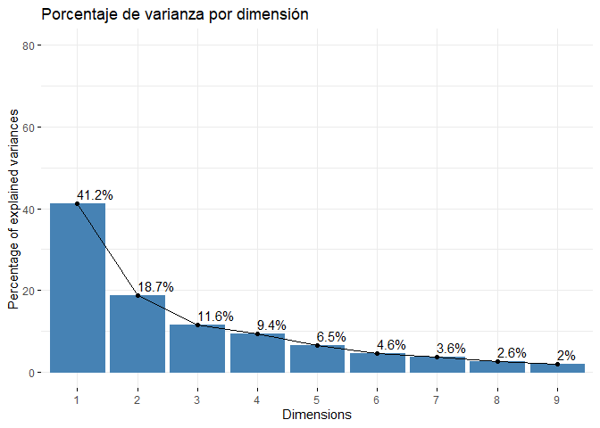

```r
# Elección del número de componentes principales
dataset_vivienda_PCA_scale <- (prcomp(dataset_PCA_scale))
fviz_eig(dataset_vivienda_PCA_scale, addlabels = TRUE, ylim = c(0, 80),
         main="Porcentaje de varianza por dimensión")
```

**NOTA:** El primer componente retiene la mayor parte de la varianza en los datos (41.2%), seguido del segundo componente con un (18.7%), el tercer componente con un (11.6%), y el cuarto componente con un (9.4%). En conjunto, estos cuatro primeros componentes abarcan el (81%) de la variabilidad total de los datos. Basándonos en esta información, se opta por seleccionar los primeros 7 componentes de los 9 disponibles, lo que proporciona una explicación del 95% de la variabilidad en los datos:

```r
# Elección del número de componentes principales
get_eigenvalue(dataset_vivienda_PCA_scale)
```

```
##       eigenvalue variance.percent cumulative.variance.percent
## Dim.1  3.7051221        41.168024                    41.16802
## Dim.2  1.6787898        18.653220                    59.82124
## Dim.3  1.0422569        11.580632                    71.40188
## Dim.4  0.8433108         9.370120                    80.77200
## Dim.5  0.5837778         6.486419                    87.25841
## Dim.6  0.4116162         4.573513                    91.83193
## Dim.7  0.3261995         3.624439                    95.45637
## Dim.8  0.2300281         2.555868                    98.01224
## Dim.9  0.1788988         1.987764                   100.00000
```

**3.1.4 Contribución de los Atributos del dataset y Componentes Principales**

En la siguiente tabla se observa la contribución de cada atributo en cada uno de los componentes seleccionados:

```r
# Selección de componentes principales
get_pca_var(dataset_vivienda_PCA_scale)$contrib[,1:7]
```

```
##                    Dim.1       Dim.2        Dim.3       Dim.4       Dim.5
## piso           1.1975944 17.46070205 10.362458692 58.74963270  5.81316264
## estrato        5.2423143 32.41017970  2.900545219  2.55123037 19.23961239
## preciom       18.2393027 10.10174414  0.134098876  1.15470257  0.06115514
## areaconst     20.3749305  0.30980302  0.708490246  0.08603833  0.04846937
## parqueaderos  13.0552130  2.77884594  0.308195450  6.37132703 60.21313582
## banios        20.3100773  0.24153885  0.006921985  3.84170337  7.23768307
## habitaciones  11.1713389 14.93073421  1.479758463 15.87998238  3.44004740
## zona_numerica  0.1379101  0.05489933 84.005252188 11.26170948  3.41184591
## tipo_numerica 10.2713189 21.71155275  0.094278880  0.10367377  0.53488825
##                      Dim.6       Dim.7
## piso           5.067356881  1.20500619
## estrato        0.351007003 11.85744822
## preciom        2.086033498  6.58918809
## areaconst     12.075515383 41.51400666
## parqueaderos   9.796287542  4.54579591
## banios         7.158257803  4.62800223
## habitaciones  25.898769682  0.05649899
## zona_numerica  0.001388144  1.02124719
## tipo_numerica 37.565384064 28.58280652
```

**3.1.5 Gráfica de los Componentes Principales - General**

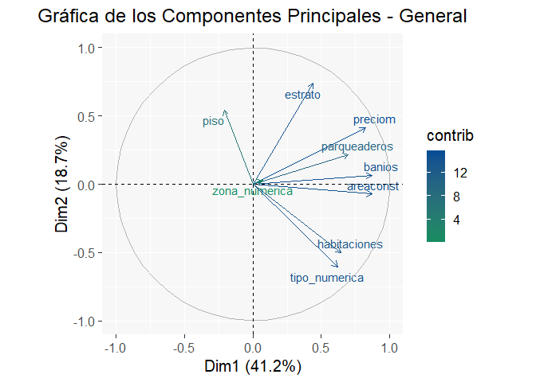

```r
# Gráfica de los Componentes Principales
grafico_pca <- fviz_pca_var(dataset_vivienda_PCA_scale, col.var = "contrib",
                        gradient.cols = c("#158E61", "#034D94"), repel = TRUE) +
  theme_gray(base_size = 15, base_family = "") +
  theme(panel.background = element_rect(fill = "#F7F7F7"),
        plot.title = element_text(hjust = 0.5)) +
  ggtitle("Gráfica de los Componentes Principales - General")
print(grafico_pca)
```

**3.1.6 Gráfica de los Componentes Principales - Individual**

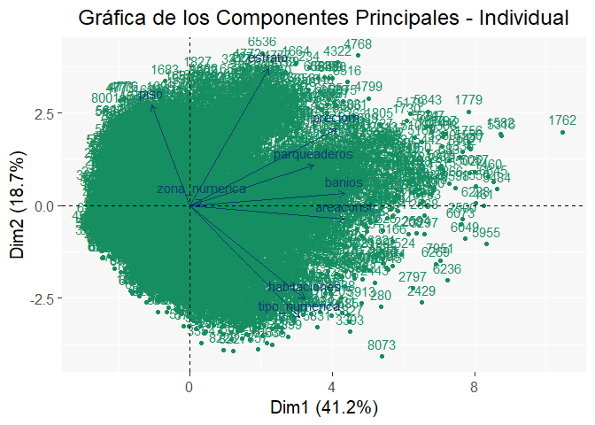

```r
# Gráfica de los Componentes Principales - Individual
grafico_pca_ind <- fviz_pca_biplot(dataset_vivienda_PCA_scale, repel=FALSE, col.var='#063C6F',
                                   col.ind='#158E61')  +
  theme_gray(base_size = 15, base_family = "") +
  theme(panel.background = element_rect(fill = "#F7F7F7"),
        plot.title = element_text(hjust = 0.5)) +
  ggtitle("Gráfica de los Componentes Principales - Individual")
print(grafico_pca_ind)
```

**3.1.6 Análisis de los Componentes Principales**

Después de llevar a cabo un análisis de los componentes principales (PCA) en la base de datos del sector inmobiliario, se han identificado patrones significativos que ofrecen una mejor comprensión de la estructura de los datos. Se ha observado que las variables relacionadas con características específicas de las propiedades, como el número de pisos, estrato, precio, área de construcción, cantidad de parqueaderos, número de baños y habitaciones, se distribuyen en varios factores o instancias.

En primer lugar, se destaca que los factores más determinantes en la oferta inmobiliaria se presentan de la siguiente manera: las propiedades con precios más altos suelen tener un área de construcción más amplia, con un mayor número de baños y parqueaderos. En segundo lugar, se encuentran el estrato, el tipo de propiedad, el número de pisos y el número de habitaciones como factores influyentes en el proceso de compra-venta de inmuebles.

Estos factores permiten comprender las preferencias y características más relevantes para los clientes, lo cual proporciona una base sólida para asesorar a los clientes y tomar decisiones estratégicas en el sector frente a los competidores.

### 3.2 Análisis de Conglomerados

**3.2.1 Adecuación del dataset para el análisis de conglomerados**

```r
# Selección de variables
dataset_Cong=select(dataset_vivienda, -zona, -tipo, -barrio, -longitud, -latitud,
                   -rango_precio,   -rango_area)

# Escalar las variables
dataset_Cong_scale <- scale(dataset_Cong)
head (dataset_Cong_scale)
```

```
##             piso    estrato    preciom  areaconst parqueaderos      banios
## [1,]  0.07232598 -1.5872276 -0.5595498 -0.7339949   -0.8559050 -0.09047352
## [2,]  0.07232598 -1.5872276 -0.3465670 -0.3842568   -0.8559050 -0.79985072
## [3,]  0.07232598 -1.5872276 -0.2552886  0.3152194    0.1313764 -0.79985072
## [4,] -0.85191340 -0.6156201 -0.1031580  0.7349051    1.1186578  1.32828088
## [5,] -1.31403309  0.3559875 -0.5291236 -0.5940997   -0.8559050 -0.79985072
## [6,] -1.31403309  0.3559875 -0.5899759 -0.6150839   -0.8559050 -0.09047352
##      habitaciones zona_numerica tipo_numerica
## [1,]    1.6595223    0.06192582     1.2586312
## [2,]   -0.4474471    0.06192582     1.2586312
## [3,]    0.2548760    0.06192582     1.2586312
## [4,]   -0.4474471    0.81508501     1.2586312
## [5,]   -0.4474471   -1.44439256    -0.7944184
## [6,]   -0.4474471   -1.44439256    -0.7944184
```

**3.2.2 Calcular las distancias Euclidianas**

```r
# Paso 3: Distancias euclidianas
dis_euc <- dist(dataset_Cong_scale, method = "euclidean")
head(dis_euc, 5)
```

```
## [1] 2.260578 2.155086 3.883624 4.140666 4.078783
```

**3.2.3 Calcular el agrupamiento para diferentes números de clústeres**

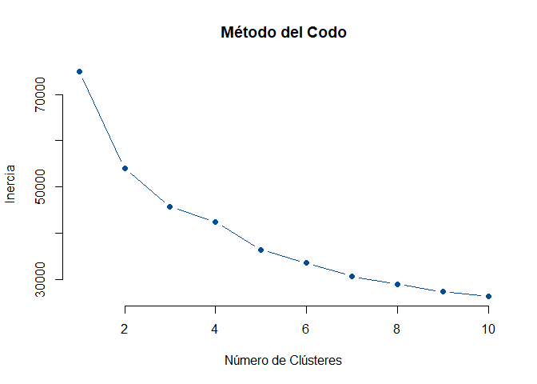

```r
# Calcular el agrupamiento para diferentes números de clústeres
set.seed(123)
kmeans_results <- lapply(1:10, function(k) kmeans(dataset_Cong_scale, centers = k))
# Calcular la inercia para cada número de clústeres
inertia <- sapply(kmeans_results, function(x) x$tot.withinss)
# Graficar la curva del codo
plot(1:10, inertia, type = "b", pch = 19, frame = FALSE,
     xlab = "Número de Clústeres",
     ylab = "Inercia",
     main = "Método del Codo", col = "#034D94")
```

**NOTA:** Para este ejercicio, se determinó que el número apropiado de clústeres es 4.

**3.2.4 Aplicar el método de agrupamiento**

**NOTA:** Como método de agrupamiento se seleccionó el de **kmeans**

```r
# Aplicación del método de agrupamiento
num_clusters <- 4
resultado_kmeans <- kmeans(dataset_Cong_scale, centers = num_clusters)

# Asignación del Cluser a cada registro del dataset scalado
dataset_Cong_scale$cluster <- resultado_kmeans$cluster
```

**3.2.5 Interpretación de resultados**

```r
# Crear tabla de frecuencias por clúster
tabla_frecuencia <- table(dataset_Cong_scale$cluster)
col_nombres <- c("Cluster", "Frecuencia")
kable(tabla_frecuencia, format = "markdown", col.names = col_nombres)
```

| Cluster | Frecuencia |
| --- | --- |
| 1 | 937 |
| 2 | 1710 |
| 3 | 3399 |
| 4 | 2273 |

**3.2.6 Visualización de los resultados**

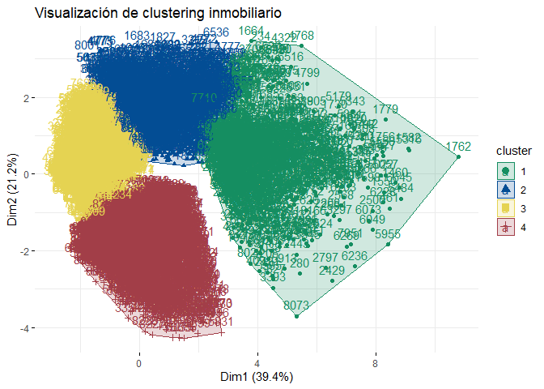

```r
dataset_vivienda$cluster <- resultado_kmeans$cluster

fviz_cluster(
  list(
    data = select(dataset_vivienda, -zona, -tipo, -barrio, -longitud, -latitud,
                   -rango_precio,   -rango_area), cluster = dataset_vivienda$cluster
  ),
  palette = c("#158E61",  "#034D94", "#E5D352", "#A23E48", "#E06D06"),
  ellipse.type = "convex",
  repel = FALSE,  # repel is a logical value, no need for quotes around FALSE
  show.clust.cent = TRUE,
  ggtheme = theme_minimal()
) + ggtitle("Visualización de clustering inmobiliario")
```

**3.2.7 Dendograma**

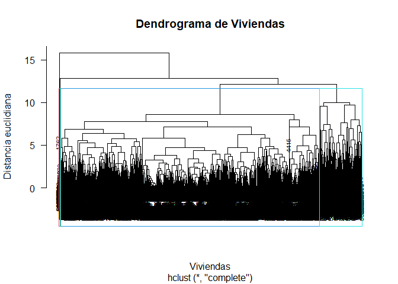

```r
# Dendograma
hierarchical_clustering <- hclust(dis_euc, method = "complete")
# Graficar dendograma
plot(hierarchical_clustering, cex = 0.6, main = "Dendrograma de Viviendas", las = 2,
     ylab = "Distancia euclidiana", xlab = "Viviendas", ylim = c(0, 50))
# Agregar rectángulos para los clústeres
rect.hclust(hierarchical_clustering, k = num_clusters, border = 2:5)
```

**NOTA:** Con el fin de analizar cada cluster por separado, se calculan medidas de tendencia central para las variables contenidas en cada cluster generado:

```r
# Análisis de clusters
median_clus <- aggregate(cbind(piso, estrato, preciom, areaconst, parqueaderos,
                               banios, habitaciones, zona_numerica, tipo_numerica)
                         ~ cluster ,data = dataset_vivienda,
                         FUN = function(x) c(Media = round(mean(x), 0)))
col_nombres <- c("Cluster", "Piso", "Estrato", "Precio", "Área construida", "Parqueaderos",
                 "Baños", "Habitaciones", "Zona", "Tipo")
kable(median_clus, format = "markdown", col.names = col_nombres)
```

| Cluster | Piso | Estrato | Precio | Área construida | Parqueaderos | Baños | Habitaciones | Zona | Tipo |
| --- | --- | --- | --- | --- | --- | --- | --- | --- | --- |
| 1 | 3 | 6 | 1025 | 441 | 4 | 5 | 5 | 4 | 2 |
| 2 | 5 | 6 | 617 | 166 | 2 | 4 | 3 | 3 | 1 |
| 3 | 4 | 4 | 217 | 80 | 1 | 2 | 3 | 4 | 1 |
| 4 | 3 | 4 | 377 | 214 | 2 | 3 | 5 | 4 | 2 |

**3.2.8 Clusters por Precio de la vivienda vs Área construida**

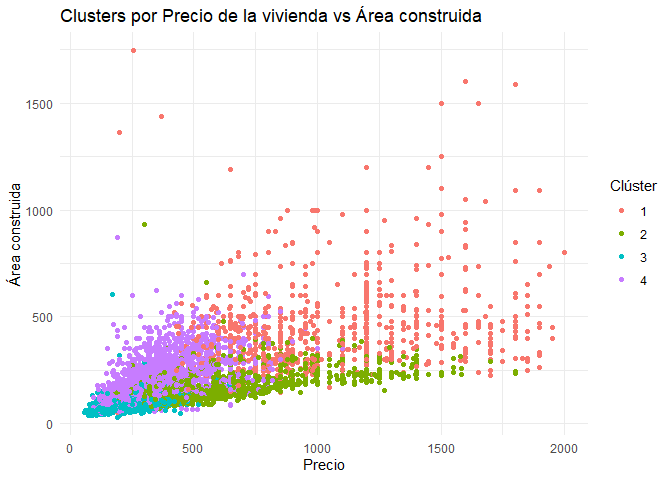

```r
# Clusters por Precio de la vivienda vs Área construida
variable1 <- dataset_vivienda$preciom
variable2 <- dataset_vivienda$areaconst

ggplot(data = dataset_vivienda, aes(x = variable1, y = variable2,
                                    color = as.factor(cluster))) + geom_point() +
  labs(x = "Precio", y = "Área construida", color = "Clúster") +
  ggtitle("Clusters por Precio de la vivienda vs Área construida") +
  theme_minimal()
```

**3.2.9 Clusters por Zona vs Tipo de vivienda**

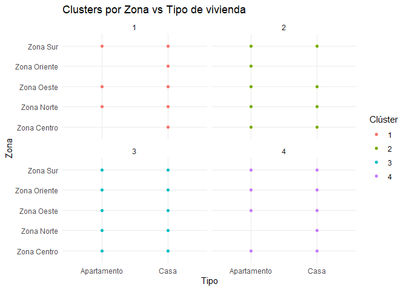

```r
# Clusters por Zona vs Tipo de vivienda
variable1 <- dataset_vivienda$zona
variable2 <- dataset_vivienda$tipo

ggplot(data = dataset_vivienda, aes(x = variable2, y = variable1, color = as.factor(cluster))) +
  geom_point() +
  labs(x = "Tipo", y = "Zona", color = "Clúster") +
  ggtitle("Clusters por Zona vs Tipo de vivienda") +
  theme_minimal() +
  facet_wrap(~ cluster, ncol = 2)
```

**3.2.10 Clusters por Número de piso vs Estrato**

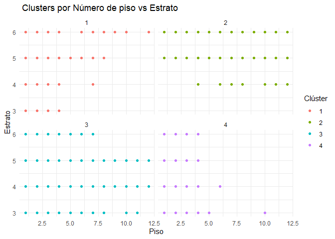

```r
#  Clusters por Número de piso vs Estrato
variable1 <- dataset_vivienda$piso
variable2 <- dataset_vivienda$estrato

ggplot(data = dataset_vivienda, aes(x = variable1, y = variable2, color = as.factor(cluster))) +
  geom_point() +
  labs(x = "Piso", y = "Estrato", color = "Clúster") +
  ggtitle(" Clusters por Número de piso vs Estrato") +
  theme_minimal() +
  facet_wrap(~ cluster, ncol = 2)
```

### 3.3 Análisis de Correspondencia

**3.3.1 Análisis de Correspondencia de zona y estrato**

Tabla de frecuencia para los atributos zona y estrato.

```r
# Tabla de frecuencia para los atributos zona y estrato.
tabla_frecuencia <- table(dataset_vivienda$zona, dataset_vivienda$estrato)
col_nombres <- c("Zona", "Est 03",  "Est 04",   "Est 05", "Est 06")
kable(tabla_frecuencia, format = "markdown", col.names = col_nombres)
```

| Zona | Est 03 | Est 04 | Est 05 | Est 06 |
| --- | --- | --- | --- | --- |
| Zona Centro | 105 | 14 | 4 | 1 |
| Zona Norte | 572 | 407 | 769 | 172 |
| Zona Oeste | 54 | 84 | 290 | 770 |
| Zona Oriente | 340 | 8 | 2 | 1 |
| Zona Sur | 382 | 1616 | 1685 | 1043 |

Se aplica prueba de asociacion chi cuadrado para determinar la relacion entre las variables zona y estrato:

```r
# Prueba de asociacion chi cuadrado
chisq.test(tabla_frecuencia)
```

```
##
##  Pearson's Chi-squared test
##
## data:  tabla_frecuencia
## X-squared = 3830.4, df = 12, p-value < 2.2e-16
```

Se evidencia que ambas variables zona y estrato se encuentran relacionadas acorde con p valor obtenido, por lo tanto se rechaza hipotesis nula que determina que son independientes la una de la otra. El nivel de significancia establecido es 0.05.

Se estiman las coordenadas para cada una de los niveles de las variables para ser representadas en un plano cartesiano

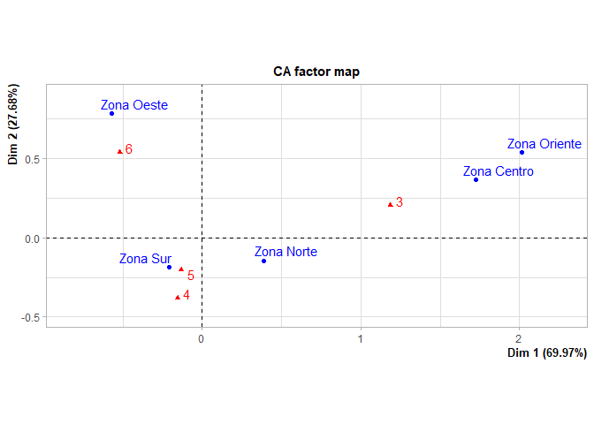

```r
# Graficación
resultados_ac <- CA(tabla_frecuencia)
```

Para medir el grado de representatividad del proceso calculas los valores de la varianza acumulada, utilizando para ellos los valores propios de la matriz de discrepancias

```r
valores_prop <-resultados_ac$eig ; valores_prop
```

```
##       eigenvalue percentage of variance cumulative percentage of variance
## dim 1 0.32215213              69.965515                          69.96551
## dim 2 0.12745096              27.680002                          97.64552
## dim 3 0.01084108               2.354483                         100.00000
```

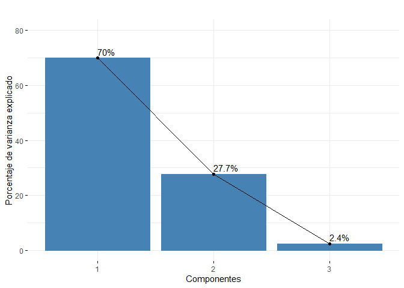

```r
fviz_screeplot(resultados_ac, addlabels = TRUE, ylim = c(0, 80))+ggtitle("")+
ylab("Porcentaje de varianza explicado") + xlab("Componentes")
```

Los resultados indican que el primer componente contiene el 70% de la varianza de los datos y el segundo componente el 27.7%, es decir que entre ambos se aporta el 97.7% de los datos.

**3.3.2 Análisis de Correspondencia de Piso y Estrato**

Tabla de frecuencia para los atributos Piso y Estrato.

```r
# Tabla de frecuencia para los atributos Piso y Estrato.
tabla_frecuencia1 <- table(dataset_vivienda$estrato, dataset_vivienda$piso)
col_nombres1 <- c("Estratos", "P01",    "P02",  "P03", "P04", "P05", "P06", "P07",
                 "P08", "P09", "P10", "P11", "P12")
kable(tabla_frecuencia1, format = "markdown", col.names = col_nombres1)
```

| Estratos | P01 | P02 | P03 | P04 | P05 | P06 | P07 | P08 | P09 | P10 | P11 | P12 |
| --- | --- | --- | --- | --- | --- | --- | --- | --- | --- | --- | --- | --- |
| 3 | 209 | 230 | 205 | 671 | 122 | 2 | 2 | 7 | 0 | 3 | 2 | 0 |
| 4 | 211 | 347 | 306 | 791 | 175 | 56 | 64 | 71 | 44 | 38 | 14 | 12 |
| 5 | 276 | 501 | 353 | 1001 | 154 | 104 | 86 | 80 | 53 | 58 | 39 | 45 |
| 6 | 164 | 372 | 233 | 779 | 116 | 83 | 52 | 53 | 49 | 31 | 29 | 26 |

Se aplica prueba de asociacion chi cuadrado para determinar la relacion entre las variables piso y estrato:

```r
# Prueba de asociacion chi cuadrado
chisq.test(tabla_frecuencia1)
```

```
##
##  Pearson's Chi-squared test
##
## data:  tabla_frecuencia1
## X-squared = 328.3, df = 33, p-value < 2.2e-16
```

Se estiman las coordenadas para cada una de los niveles de las variables para ser representadas en un plano cartesiano

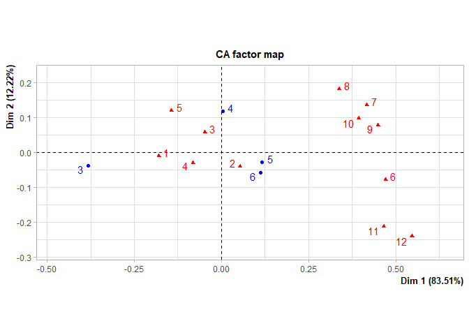

```r
# Graficación
resultados_ac1 <- CA(tabla_frecuencia1)
```

Para medir el grado de representatividad del proceso calculas los valores de la varianza acumulada, utilizando para ellos los valores propios de la matriz de discrepancias

```r
valores_prop1 <-resultados_ac1$eig ; valores_prop
```

[output not shown]

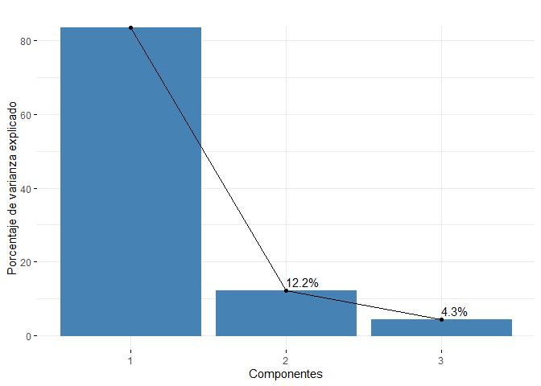

```r
fviz_screeplot(resultados_ac1, addlabels = TRUE, ylim = c(0, 80))+ggtitle("")+
ylab("Porcentaje de varianza explicado") + xlab("Componentes")
```

Los resultados indican que el primer componente contiene el 83,5% de la varianza de los datos y el segundo componente el 12.2%, es decir que entre ambos se aporta el 95.7% de los datos.

**3.3.3 Análisis de Correspondencia de Precio y Área construida**

Tabla de frecuencia para los atributos Precio y Área construida.

```r
# Tabla de frecuencia para los atributos Precio y Área construida
tabla_frecuencia2 <- table(dataset_vivienda$rango_precio, dataset_vivienda$rango_area)
col_nombres2 <- c("Precio vs Area", "<100", "100-300",  "300-600",  "600-900",
                  "900-1200",   "1200-1500",    "1500-1800",    ">1800")
kable(tabla_frecuencia2, format = "markdown", col.names = col_nombres2)
```

| Precio vs Area | <100 | 100-300 | 300-600 | 600-900 | 900-1200 | 1200-1500 | 1500-1800 | >1800 |
| --- | --- | --- | --- | --- | --- | --- | --- | --- |
| <100 | 166 | 3 | 0 | 0 | 0 | 0 | 0 | 0 |
| 100-300 | 2662 | 862 | 25 | 2 | 1 | 1 | 1 | 0 |
| 300-600 | 462 | 2085 | 372 | 2 | 0 | 1 | 0 | 0 |
| 600-900 | 3 | 627 | 288 | 27 | 3 | 0 | 0 | 0 |
| 900-1200 | 0 | 175 | 158 | 25 | 9 | 0 | 0 | 0 |
| 1200-1500 | 0 | 88 | 106 | 25 | 6 | 2 | 0 | 0 |
| 1500-1800 | 0 | 13 | 71 | 11 | 5 | 1 | 2 | 0 |
| >1800 | 0 | 4 | 19 | 5 | 1 | 0 | 0 | 0 |

Se aplica prueba de asociacion chi cuadrado para determinar la relacion entre las variables Precio y Área construida:

```r
# Prueba de asociacion chi cuadrado
chisq.test(tabla_frecuencia2)
```

```
##
##  Pearson's Chi-squared test
##
## data:  tabla_frecuencia2
## X-squared = NaN, df = 49, p-value = NA
```

Se estiman las coordenadas para cada una de los niveles de las variables para ser representadas en un plano cartesiano

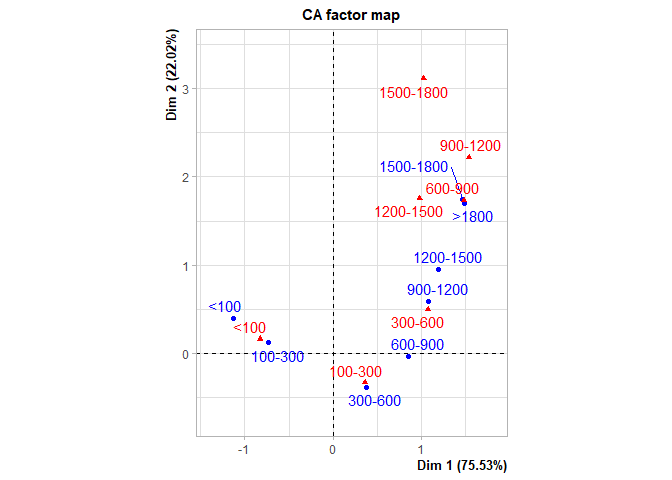

```r
# Graficación
resultados_ac2 <- CA(tabla_frecuencia2)
```

Para medir el grado de representatividad del proceso calculas los valores de la varianza acumulada, utilizando para ellos los valores propios de la matriz de discrepancias

```r
valores_prop2 <-resultados_ac2$eig ; valores_prop
```

[output not shown]

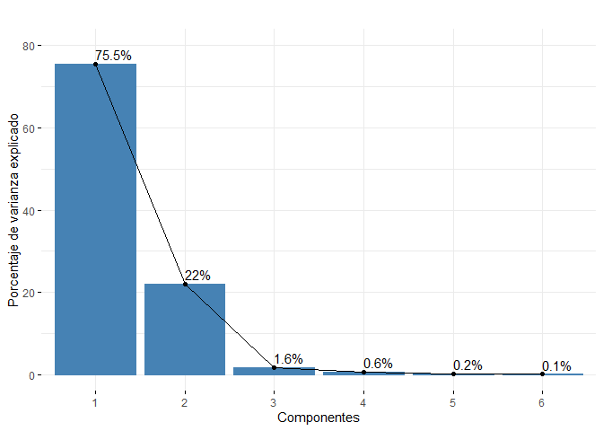

```r
fviz_screeplot(resultados_ac2, addlabels = TRUE, ylim = c(0, 80))+ggtitle("")+
ylab("Porcentaje de varianza explicado") + xlab("Componentes")
```

Los resultados indican que el primer componente contiene el 75,5% de la varianza de los datos y el segundo componente el 22%, es decir que entre ambos se aporta el 97.5% de los datos.

## 4. Análisis Final

En conclusión, el análisis exhaustivo realizado sobre la base de datos de la empresa inmobiliaria ha proporcionado valiosas perspectivas que pueden informar estrategias comerciales y decisiones estratégicas en el sector. La base de datos, compuesta por 8,322 registros y 13 atributos, revela una combinación de variables numéricas y categóricas que influyen en la dinámica del mercado. Sin embargo, se observa una pérdida de información en algunos atributos, como el piso y el parqueadero, lo que sugiere la necesidad de abordar las inconsistencias antes de realizar análisis más detallados.

El análisis de componentes principales (PCA) ha identificado patrones significativos en la estructura de los datos, destacando la relación entre el precio, el área de construcción, los baños, los parqueaderos y otras características específicas de las propiedades. Estos factores proporcionan una comprensión más profunda de las preferencias y necesidades de los clientes, lo que puede guiar la formulación de estrategias de marketing y ventas más efectivas.

El análisis de conglomerados ha segmentado las propiedades en cuatro clusters distintos, cada uno con características únicas en términos de precio, tamaño y ubicación. Estos clusters revelan la diversidad del mercado inmobiliario y las diferentes preferencias de los compradores, lo que subraya la importancia de adaptar las estrategias de comercialización a cada segmento.

Finalmente, el análisis de correspondencia ha proporcionado una visión detallada de la relación entre variables categóricas, como la zona y el estrato, lo que puede ayudar a identificar patrones geográficos y demográficos en el mercado.

Por lo anterior, estos análisis ofrecen una base sólida para comprender y aprovechar las oportunidades en el sector inmobiliario, permitiendo a la empresa tomar decisiones informadas y satisfacer las necesidades cambiantes de los clientes en un mercado competitivo.

# Anexos

Código fuente --> [Clic Aquí](https://raw.githubusercontent.com/aperezn298/METDAct01/main/ACtividad01.Rmd)

# Autor

Alvaro Perez Niño – Estudiante

Maestría en Ciencia de Datos

Universidad Javeriana - Cali

Código: 8986470

Email: aperezn892@javerianacali.edu.co